# Introduction to AlpsLCMS

Institute for Bioengineering of Catalonia

2020-11-25

The `AlpsLCMS` package was written with two purposes in mind:

- to help **data analysts and LC-MS scientists** to work with LC-MS samples.
- to help **IT pipeline builders** implement automated methods for preprocessing.

Functions from this package written for data analysts and LC-MS scientists are prefixed with `lcms_`, while higher level functions written for IT pipeline builders are prefixed with `pipe_`. The main reason why all exported functions have a prefix is to make it easy for the user to discover the functions from the package. By typing lcms_ RStudio will return the list of exported functions. In the R terminal, lcms_ followed by the tab key (⇥) twice will have the same effect. Other popular packages, follow similar approaches (e.g: `forcats`: `fct_*`, `stringr`: `str_*`).

This vignette is written for the first group. It assumes some prior basic knowledge of LC-MS and data analysis, as well as some basic R programming. In case you are interested in building pipelines with this package, you may want to open the file saved in this directory (run it on your computer):

```
pipeline_example <- system.file("pipeline-rmd", "pipeline_example.R", package = "AlpsLCMS")
print(pipeline_example)
```

```r
library(AlpsLCMS)
```

# NODE 1: Data wrangling

## Convert RAW to mzXML

First, we need the listed spectra in “.mzXML” format to create the `lcms_dataset`. We can manually convert “.raw” into “.mzXML” using RawConverter or ProteoWizard externally and saved them within the same input directory. We set the polarity manually.

## Input

```r
library(faahKO)
path <- dir(system.file("cdf", package = "faahKO"), full.names = TRUE,
            recursive = TRUE)
polarity <- 1 # 1 for positive mode, 0 for negative mode
```

## Code to run

```r
# Be careful setting the mode to "onDisk" when you apply this function.
dataset <- readMSData(path, mode = "onDisk")
```

```
#> Polarity can not be extracted from netCDF files, please set manually the polarity with the 'polarity' method.
```

```r
dataset@featureData@data[["polarity"]] <- rep(polarity, length(dataset@featureData@data[["polarity"]]))
head(dataset)
```

```
#> MSn experiment data ("OnDiskMSnExp")
#> Object size in memory: 0.03 Mb
#> - - - Spectra data - - -
#>  MS level(s): 1
#>  Number of spectra: 6
#>  MSn retention times: 41:41 - 41:49 minutes
#> - - - Processing information - - -
#> Data loaded [Wed Nov 25 12:47:44 2020]
#>  MSnbase version: 2.10.1
#> - - - Meta data  - - -
#> phenoData
#>   rowNames: ko15.CDF
#>   varLabels: sampleNames
#>   varMetadata: labelDescription
#> Loaded from:
#>   ko15.CDF
#> protocolData: none
#> featureData
#>   featureNames: F01.S0001 F01.S0002 ... F01.S0006 (6 total)
#>   fvarLabels: fileIdx spIdx ... spectrum (31 total)
#>   fvarMetadata: labelDescription
#> experimentData: use 'experimentData(object)'
```

# NODE 2: Append metadata

To merge the metadata, an Excel o CSV file is required, containing the first column (called “sampleNames”) with the same name of the LC-MS files, **ending with the format (e.g. Sample1.mzXML)**.

It requires a column (called “treatment”) with the class sample. Ensure you have this specific colname **“treatment”**.

Caution with metadata. The use of characters such as “-”, “/”, " " (space) and starting with **numbers**, etc. leads to problems. Therefore, the function replace `[\\\"\\s/\\\\,;.:|#@$%&?!*%+-=><^'(){}\\[\\]]+` by `_`. Beware of using other special characters and change them by usual ASCII characters.

## Input parameters

```r
metadata <- data.frame(sampleNames = basename(path),
                 treatment = c(rep("ko",6),
                               rep("wt",6)),
                 stringsAsFactors = FALSE)
```

## Code to run

```r
dataset <- lcms_meta_add(dataset, metadata, by = "sampleNames")
phData(dataset)
```

```
#>    sampleNames treatment
#> 1     ko15.CDF        ko
#> 2     ko16.CDF        ko
#> 3     ko18.CDF        ko
#> 4     ko19.CDF        ko
#> 5     ko21.CDF        ko
#> 6     ko22.CDF        ko
#> 7     wt15.CDF        wt
#> 8     wt16.CDF        wt
#> 9     wt18.CDF        wt
#> 10    wt19.CDF        wt
#> 11    wt21.CDF        wt
#> 12    wt22.CDF        wt
```

# NODE 3: Total ion chromatogram

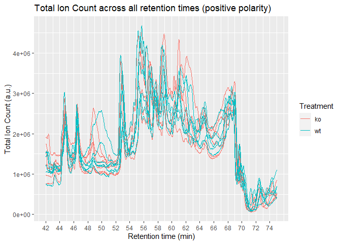

```r
tics <- lcms_tics(dataset, treatment = "treatment")

lcms_plot_tics(tics,
               treatment = treatment,
               plot_type = "spec")
```

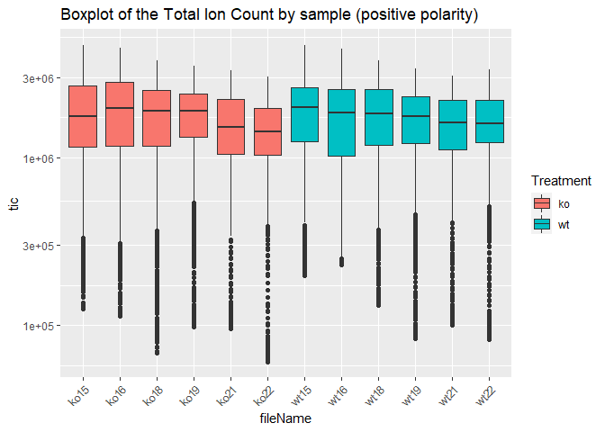

```r
lcms_plot_tics(tics, treatment = treatment,
               plot_type = "boxplot")
```

# NODE 4: Filtering

## Filter by retention time / m/z

For coherence with the pipeline, time is measured in minutes. `XCMS` and `IPO` packages work in seconds by default, while `CAMERA` and `MAIT` in minutes. Under the hood, the still do in this way, but we preset all our results in minutes.

## Input

```r
# Range of the retention time (minutes) to include in further analyses
rt = c(50, 60)
ms = c(200, 500)
```

## Code to run

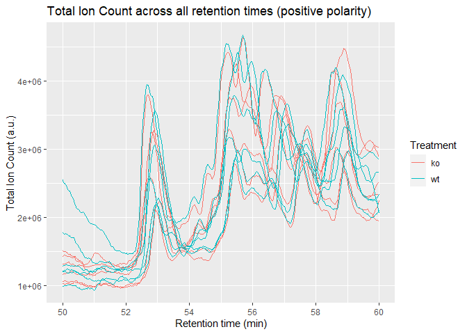

```r
dataset_shorter <- lcms_filter_rt_min(dataset, rt = rt)
dataset_shorter <- lcms_filter_mz(dataset_shorter, mz = ms)
tics <- lcms_tics(dataset_shorter, treatment = "treatment")

lcms_plot_tics(tics,
               treatment = treatment,
               plot_type = "spec")
```

# NODE 5: Data Preprocessing - XCMS

It includes:

- Peak Detection
- Retention Time Correction
- Peak Correspondence
- Imputation

Parameters can be changed here. After manual inspection of certain compounds that we know that they should naturally appear, such as plotting leucine and isoleucine (as we are using plasma samples), we can set parameters more accurally.

## Input

```r
prep_parm_p <- NULL
prep_parm_p$peakwidth <- c(20, 80)
prep_parm_p$noise <- 5000
prep_parm_p$snthresh <- 3
prep_parm_p$prefilter <- c(6, 5000)
prep_parm_p$centerSample <- "wMean"
prep_parm_p$integrate <- 2
prep_parm_p$mzdiff <- -0.001
prep_parm_p$profStep <- 0.005
prep_parm_p$minFraction <- 0.2
prep_parm_p$ppm <- 25
prep_parm_p$mzCenterFun <- "wMean"
prep_parm_p$fitgauss <- FALSE
prep_parm_p$verbose.columns <- FALSE

classes <- dataset@phenoData@data[["treatment"]]
```

# **Peak detection**

Our standard method for peak detection is *‘CentWave’*, since the data provided is centroided. We must initialize its parameters according to the `IPO` Package optimization. Peak detection aims to detect important features (peaks) on the chromatographic axis.

## Code to run

```r
peakdet = find_peaks_cwp(dataset,
                         params = prep_parm_p)
```

```
#>
#>  Finding chromatographic peaks
```

```r
message("Number of detected peaks")
```

```
#> Number of detected peaks
```

```r
peakdet@msFeatureData[["chromPeakData"]]@nrows
```

```
#> [1] 7952
```

```r
message("")
message("Parameters")
```

```
#> Parameters
```

```r
peakdet@.processHistory[[1]]@param
```

```
#> Object of class:  CentWaveParam
#> Parameters:
#>  ppm: 25
#>  peakwidth: 20, 80
#>  snthresh: 3
#>  prefilter: 6, 5000
#>  mzCenterFun: wMean
#>  integrate: 2
#>  mzdiff: -0.001
#>  fitgauss: FALSE
#>  noise: 5000
#>  verboseColumns: FALSE
#>  roiList length: 0
#>  firstBaselineCheck TRUE
#>  roiScales length: 0
```

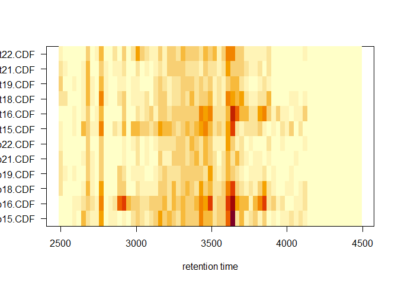

```r
xcms::plotChromPeakImage(peakdet)
```

# **Retention Time Correction and Peak Correspondence**

Peak correspondence is carried out by the *‘groupChromPeaks’* method, with parameters obtained form `IPO`. Peak Correspondece consist in grouping peaks on retention time axis with the purspose of associate them to spectra on the mass/chage axis. After this stage we finally have a peak table.

It requires a previous grouping.

# **Correspondence, Alignment and Regrouping**

## **Correspondence**

```r
new_params <- PeakDensityParam(sampleGroups = classes,
                               binSize = 0.6)

peakgrouped = groupChromPeaks(peakdet,
                              param = new_params)
```

```
#> Processing 1333 mz slices ... OK
```

## **Alignment and regrouping**

```r
pgp <- PeakGroupsParam(minFraction = 0.8,
                       extraPeaks = 1,
                       smooth = "loess",
                       span = 0.4,
                       family = "gaussian")

## Get the peak groups that would be used for alignment.
xdata_aling <- adjustRtime(peakgrouped, param = pgp)
```

```
#> Performing retention time correction using 47 peak groups.
#> Applying retention time adjustment to the identified chromatographic peaks ... OK
```

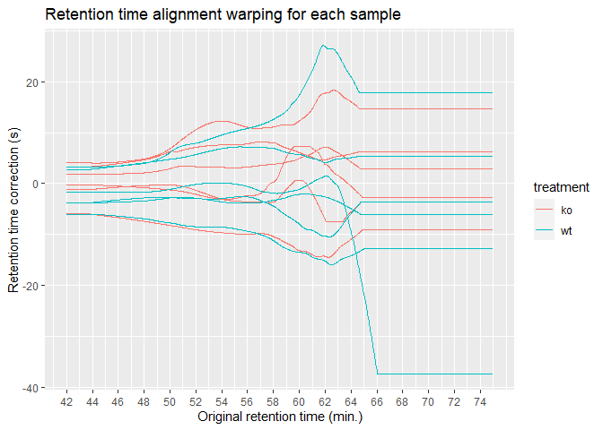

```r
rt_plot = lcms_retention_time_alignment_plot(xdata_aling)
rt_plot
```

```r
## REGROUPING
new_params <- PeakDensityParam(sampleGroups = classes,
                               bw = 30, #
                               minFraction = 0.4)

peakgrouped = groupChromPeaks(xdata_aling, param = new_params)
```

```
#> Processing 3196 mz slices ... OK
```

Image plot of the chromatographic detected peaks per sample before retention time alignment and grouping:

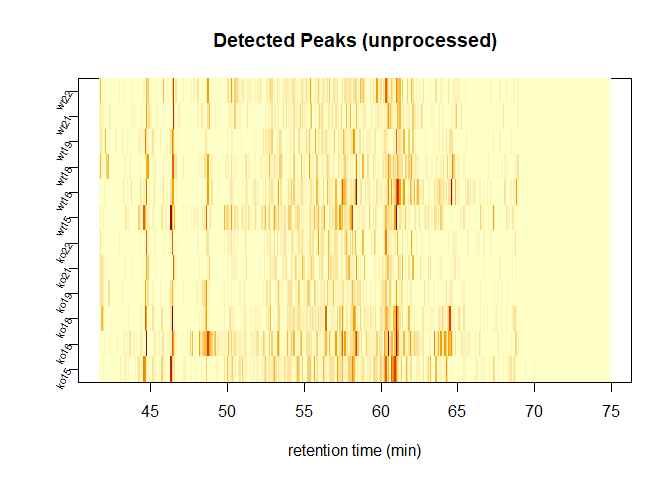

```r
lcms_plot_chrom_peak_image(peakdet, binSize = 5,
                           xlim = NULL,
                           log = FALSE,
                           xlab = "retention time (min)",
                           yaxt = par("yaxt"),
                           main = "Detected Peaks (unprocessed)")
```

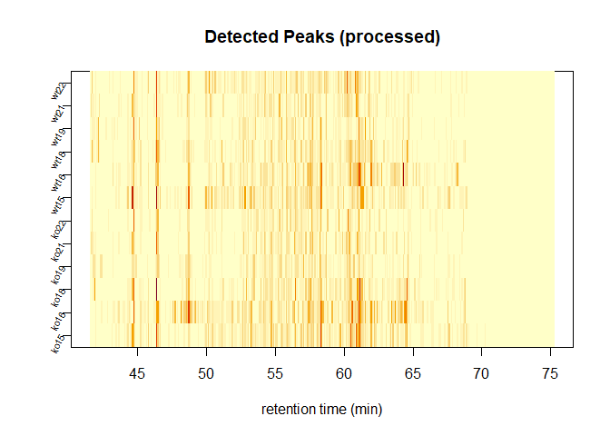

```r
lcms_plot_chrom_peak_image(peakgrouped, binSize = 5,
                           xlim = NULL,
                           log = FALSE,
                           xlab = "retention time (min)",
                           yaxt = par("yaxt"),
                           main = "Detected Peaks (processed)")
```

# *Imputation*

Finally, in the imputation stage, we integrate the areas of the missing peaks of the peak table that were not detected in the previous steps of the signal preprocessing workflow. This stage is important to make easier statistical and machine learnig posterior stages.

```r
message("Missing values found in the processed dataset: ", sum(is.na(featureValues(peakgrouped))))
```

```
#> Missing values found in the processed dataset: 1841
```

```r
peakgrouped_imp <- lcms_fill_chrom_peaks(peakgrouped)
```

```
#>
#>  Imputing missing peaks of the peak table.
```

```r
cat("Imputing values...\n")
```

```
#> Imputing values...
```

```r
message("Missing values found after fill_chrom_peaks: ", sum(is.na(featureValues(peakgrouped_imp))))
```

```
#> Missing values found after fill_chrom_peaks: 166
```

# NODE 8: Feature table

The function `feature_values` creates a intensity matrix with all the features. However, since this is untargeted metabolomics, the colnames are composed by FT1, FT2, FT3… (FT = feature) and each feature needs to be explored with the feature definition function (info for mass and rt) once a feature is significantly different by groups.

## Merging into a Feature Table

```r
xdata = feature_values(peakgrouped_imp,
                      method = "maxint",
                      value = "into",
                      filled = TRUE,
                      missing = "rowmin_half")
xdata <-  t(xdata)
feature <- featureDefinitions(peakgrouped_imp)
feature <- feature@listData
featNames <- paste0(feature$mzmed,"_",feature$rtmed)
colnames(xdata) <- featNames

message("Missing values in the feature table: ",
sum(is.na(xdata)))
```

```
#> Missing values in the feature table: 0
```

# NODE 9: Data reduction

## Input

```r
st <- getRamSt(peakgrouped_imp)
```

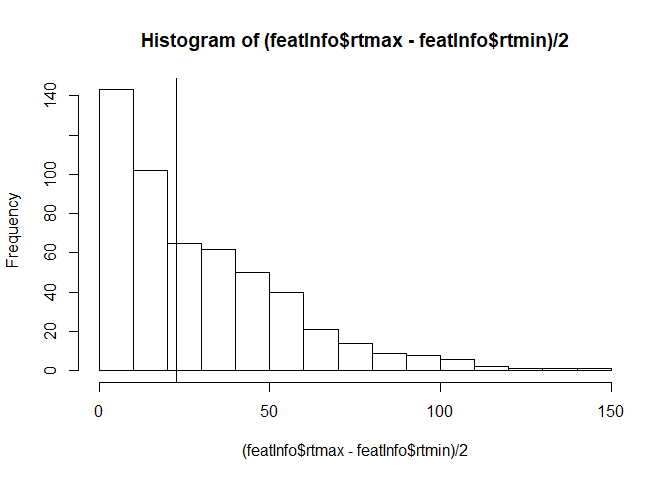

```r
sr <- 0.6

#List of adducts for do.findmain
#adducts_list = c("[M+H-H2O]+")
adducts_list = c()

## Building the defineExperiment manually
## Change for your convenience (e.g. GC-MS)
value <- c(rep("fill", 4), "LC-MS")
design <- as.data.frame(value)
rownme <- c("Experiment", "Species", "Sample",
            "Contributer", "platform")
rownames(design) <- rownme

value <- c(rep("fill", 13), "1")
instrument <- as.data.frame(value)
rownm <- c("chrominst", "msinst", "column",
           "solvA", "solvB", "CE1", "CE2",
           "mstype", "msmode", "ionization",
           "colgas", "msscanrange", "conevol",
           "MSlevs")
rownames(instrument) <- rownm

Experiment <- list(design =  design, instrument = instrument)
```

## Code to run

```r
RC <- clustering(xcmsObj = peakgrouped_imp,
                 featdelim = ".",
                 st = st,
                 sr = sr,
                 ExpDes = Experiment,
                 normalize = "TIC",
                 deepSplit = TRUE,
                 sampNameCol = 1,
                 mspout = FALSE,
                 fftempdir = getwd())
```

```
#>   organizing dataset
#>   normalizing dataset
#> calculating ramclustR similarity: nblocks =  1
#> 1
#>  RAMClust feature similarity matrix calculated and stored:
#> RAMClust distances converted to distance object
#> fastcluster based clustering complete
#> dynamicTreeCut based pruning complete
#> RAMClust has condensed 525 features into 121 spectra
#> collapsing feature into spectral signal intensities
```

```r
RC <- do_findmain(RC,
                  nls = c("[M+H-H2O]+"),
                  mode = "positive",
                  mzabs.error = 0.01,
                  ppm.error = 10,
                  plot.findmain = FALSE,
                  writeMat = FALSE,
                  writeMS = FALSE)
```

```
#> 10 of 121
#> 20 of 121
#> 30 of 121
#> 40 of 121
#> 50 of 121
#> 60 of 121
#> 70 of 121
#> 80 of 121
#> 90 of 121
#> 100 of 121
#> 110 of 121
#> 120 of 121
#> finished
```

```r
reduced_object  <- feature_reduction(RC, xdata, loaded = FALSE)
```

```
#> length of features: 525
#> A number of 371 features have been clustered into 13 representative features
#> A number of 493 features correspond to singletons
#> Original dataset has 525 features
#>
#> Molecular ions dataset has 13 features
#> Singletons dataset has 493 features
#> Reduced dataset has 506 features
```

```r
xdata_reduced <- reduced_object$xdata_reduced
```

## Univariante analysis

```r
stat <- function(x){stats::wilcox.test(x ~ classes, xdata_reduced)$p.value}
abcd <- data.frame(apply(FUN = stat,
                         MARGIN = 2,
                         X = xdata_reduced))
colnames(abcd) <- c("p_Wilc")
abcd$id <- row.names(abcd)
result <- abcd
summary(result$p_Wilc)
```

```
#>     Min.  1st Qu.   Median     Mean  3rd Qu.     Max.
#> 0.002165 0.309524 0.588745 0.567469 0.818182 1.000000
```

```r
message("\nNumber of features < 0.05 nominal p-value ",
sum(result$p_Wilc < 0.05))
```

```
#>
#> Number of features < 0.05 nominal p-value 40
```

```r
head(result[result$p_Wilc < 0.05, 1])
```

```
#> [1] 0.002164502 0.002164502 0.002164502 0.002164502 0.002164502 0.002164502
```

```r
#FDR
fdr.wilcox <- stats::p.adjust(result$p_Wilc, method = "fdr")
result <- cbind(result, fdr.wilcox)
message("\nNumber of features fdr-corrected p value of < 0.05 is ",
sum(result$fdr.wilcox < 0.05))
```

```
#>
#> Number of features fdr-corrected p value of < 0.05 is 26
```

# Univariate anotation

```r
# We use the selected vips
univ_feat <- result[result$fdr.wilcox < 0.05,"id"]

# Untargeted assignation
# Creating mz column
mzr <- univ_feat %>%
  stringr::str_split(.,"\\_") %>%
  lapply(.,function(x) x[1]) %>%
  unlist() %>%
  as.numeric()

all.equal(length(univ_feat), length(mzr))
```

```
#> [1] TRUE
```

```r
tdata_reduced_univ <- data.frame(mz = mzr)
if(dim(tdata_reduced_univ)[1]>0){
  result_POS_HMDB_univ <- assignation_pos_HMDB(tdata_reduced_univ)
  head(result_POS_HMDB_univ)
} else {
  message("There is no significant features in Wilcox test")
}
```

```
#>      mz       HMDB
#> 1 298.2       <NA>
#> 2 300.2       <NA>
#> 3 301.2       <NA>
#> 4 302.2       <NA>
#> 5 322.1 HMDB12143
#> 6 324.2       <NA>
#>                                                                                        Assignation
#> 1                                                                                             <NA>
#> 2                                                                                             <NA>
#> 3                                                                                             <NA>
#> 4                                                                                             <NA>
#> 5  2-Amino-4-oxo-4-alpha-hydroxy-6-(erythro-1',2',3'-trihydroxypropyl)-5,6,7,8-tetrahydroxypterin
#> 6                                                                                             <NA>
```

# anotation of all features positive

```r
# Untargeted assignation
# Creating mz column

mzr <- colnames(as.matrix(xdata)) %>%
  stringr::str_split(.,"\\_") %>%
  lapply(.,function(x) x[1]) %>%
  unlist() %>%
  as.numeric()

tdata_reduced_all_features <- data.frame(mz = mzr)
result_POS_HMDB_all_features <- assignation_pos_HMDB(tdata_reduced_all_features)
head(result_POS_HMDB_all_features)
```

```
#>      mz HMDB Assignation
#> 1 200.1 <NA>        <NA>
#> 2 205.0 <NA>        <NA>
#> 3 206.0 <NA>        <NA>
#> 4 207.1 <NA>        <NA>
#> 5 219.1 <NA>        <NA>
#> 6 231.0 <NA>        <NA>
```

# Final thoughts

This vignette shows many of the features of the package, some features have room for improvement, others are not fully described, and the reader will need to browse the documentation. Hopefully it is a good starting point for using the package.